# Trabajo Final Godoy-Matus

Vicente Godoy- Ignacio Matus

2025-06-23

# Introducción

En la última década, Chile ha experimentado transformaciones sociales y políticas profundas, marcadas por movilizaciones ciudadanas, procesos constituyentes y un creciente descontento con las instituciones tradicionales. Según el Informe de Desarrollo Humano del PNUD (2024), estos cambios se ven obstaculizados por dos factores clave: *1) relaciones disfuncionales entre élites, movimientos sociales y ciudadanía, y 2) lógicas institucionales y discursivas que inhiben la acción colectiva efectiva (PNUD, p. 230)*. *En paralelo, fenómenos como el envejecimiento poblacional y la baja fecundidad (PNUD, p. 40)* replantean el rol de las juventudes como actor crítico en la construcción democrática.

Este trabajo explora la dimensión política de las juventudes chilenas (15-29 años), analizando su integración al sistema democrático a través de datos de la Décima Encuesta Nacional de Juventudes (INJUV, 2022). La pregunta central que guía nuestra investigación es: **¿Cómo se distribuye territorialmente la integración política de las juventudes en Chile?**

Nuestros **objetivos** son:

- Identificar donde es que se concentra la mayor y menor integración política de jóvenes en Chile
- Explorar diferencias en los niveles de integración política entre hombres y mujeres jóvenes en Chile.

Para responderlos, empleamos un **análisis descriptivo** de variables clave (participación en organizaciones, confianza en instituciones y actitudes hacia la democracia). Los hallazgos buscan aportar evidencia empírica para políticas públicas que fomenten la inclusión juvenil, especialmente en regiones con menor participación.

# Metodología

Para este trabajo hemos utilizado la base de datos proveniente de la Décima Encuesta Nacional de Juventudes (INJUV, 2022) , una herramienta metodológica validada por su riguroso diseño muestral probabilístico estratificado, lo cual garantiza representatividad nacional y regional (INJUV, 2022). De esta encuesta, seleccionamos el módulo temático N°4: “Política y procesos de integración al sistema democrático” , compuesto originalmente por las preguntas P22 a P30.

*En nuestro análisis, nos concentramos únicamente en las preguntas P22 a P29*, ya que la pregunta P30 resultó especialmente amplia y abierta , planteando desafíos metodológicos para su codificación estandarizada y su posterior articulación en variables operativas. Por lo tanto, decidimos excluir esta última pregunta con el fin de asegurar consistencia y comparabilidad en los resultados obtenidos.

Las **variables seleccionadas** para nuestro trabajo son:

**Regiones** (agrupadas según criterios geográficos: Norte, Centro, RM y Sur),**Sexo** (hombres y mujeres), y **Un índice de integración política** , construido a partir de las respuestas a las preguntas del módulo temático N°4. Este índice sintetiza dimensiones clave como el interés por la política, la participación en organizaciones y la confianza en instituciones democráticas.

# Script

### Paso 0 - Instalación y carga de paquetes

Lo primero, antes de empezar es cargar las librerías que utilizaremos para nuestro trabajo, una vez hecho esto podemos comenzar con la preparación inicial.

```r
# Cargar paquetes necesarios
if (!require(pacman)) install.packages("pacman")
```

```r
pacman::p_load(
  tidyverse,    # Manipulación y visualización de datos
  sjlabelled,   # Etiquetado de variables
  scales,       # Escalas para gráficos
  ggplot2,      # Creación de gráficos
  sjmisc       # Funciones útiles para análisis
)
```

### Paso 1 - El directorio de trabajo y los datos

Una vez cargadas las librerías es importante crear el directorio donde guardemos nuestro trabajo, en el debe ir la base de datos, y los elementos necesarios para nuestro trabajo, como el libro de códigos y los posibles backups, usamos setwd para elegir el directorio y getwd para confirmar que lo hicimos bien.

```r
setwd("C:/Users/Vicente/Desktop/R cosas/R-practicos/Trabajo Final")
getwd()
```

```
## [1] "C:/Users/Vicente/Desktop/R cosas/R-practicos/Trabajo Final"
```

### Paso 2 - Abrir base de datos

Ahora para comenzar con nuestro trabajo, tenemos que cargar la base de datos con la que trabajaremos, para nuestro caso es la base de datos de la décima Encuesta Nacional de Juventudes.

```r
injuvdata <- read_data("C:/Users/Vicente/Desktop/R cosas/R-practicos/Trabajo Final/input/Jóvenes/BBDD Respuesta - Encuesta Jóvenes.dta")
```

```
## Following 1 variables have only missing values:
```

```
## P80_COD
```

```
## Converting atomic to factors. Please wait...
```

### Paso 3 - Separar las Variables

Una vez subida la base de datos tenemos que elegir las variables que utilizaremos, para su posterior re-codificación y limpieza, tambien podemos hacer un respaldo de la base de datos para prevenir posibles desastres.

```r
Respaldo <- injuvdata
variables <- injuvdata %>% select(REGION, SEXO, P22,P23,P24_1,P24_2,P24_3,P24_4,P25,P26,P27,P28_1,P28_2,P29)
```

### Paso 4.1 - Recodificacion de variables (REGION)

```r
variables <- variables %>%
  mutate(Regiones = case_when(
    REGION %in% c(1,2,3,4) ~ "Norte",
    REGION %in% c(5,6,7,8,16) ~ "Centro",
    REGION == 13 ~ "RM",
    TRUE ~ "Sur"
  ))
```

### Paso 4.2 - Recodificacion de variables (SEXO)

En paso nos enfocaremos en hacer la modificación simple en las categorías de sexo 1=Hombre, 2=Mujer, esto con la intención de que a la hora de visualizar los resultados, poder hacer divisiones por sexo, ademas de las regiones.

```r
variables <- variables %>%
  mutate(Sexo = case_when(
    SEXO == 1 ~ "Hombre",
    SEXO == 2 ~ "Mujer",
    TRUE ~ NA_character_
  ))
```

### Paso 4.3 - Recodificacion de variables (Preguntas por la participacion politca)

Probablemente este sea el paso más largo, dado de que tenemos que re-codificar un gran numero de variables,la recodificacion se hara por orden ascendente para mayor claridad.

```r
# P22: Participación en organizaciones
variables <- variables %>%
  mutate(Participacion_Org = case_when(
    P22 == 1 ~ 1,   # Sí
    P22 == 2 ~ 0,   # No
    TRUE ~ NA_real_ # Otros casos (NS/NR)
  ))

#P23: Cargo de dirigente
variables <- variables %>%
  mutate(Cargo_Dirigente = case_when(
    P23 == 1 ~ 1,
    P23 == 2 ~ 0,
    TRUE ~ NA_real_
  ))

#P24_1 a P24_4: Movilización y voto
variables <- variables %>%
  mutate(
    Movilizacion = case_when(P24_1 == 1 ~ 1, P24_1 == 2 ~ 0, TRUE ~ NA_real_),
    Organizo_Movilizacion = case_when(P24_2 == 1 ~ 1, P24_2 == 2 ~ 0, TRUE ~ NA_real_),
    Voto_Eleccion = case_when(P24_3 == 1 ~ 1, P24_3 == 2 ~ 0, TRUE ~ NA_real_),
    Info_Antes_Votar = case_when(P24_4 == 1 ~ 1, P24_4 == 2 ~ 0, TRUE ~ NA_real_)
  )

#P25 y P26: Confianza en instituciones
variables <- variables %>%
  mutate(
    Confianza_Congreso = case_when(
      P25 %in% 1:2 ~ 0,    # Ninguna o poca confianza
      P25 == 3 ~ 1,         # Alguna confianza
      P25 %in% 4:5 ~ 2,     # Mucha o bastante confianza
      TRUE ~ NA_real_
    ),
    Confianza_Partidos = case_when(
      P26 %in% 1:2 ~ 0,
      P26 == 3 ~ 1,
      P26 %in% 4:5 ~ 2,
      TRUE ~ NA_real_
    )
  )

#P27: Satisfacción con la democracia
variables <- variables %>%
  mutate(Satisfaccion_Democracia = case_when(
    P27 %in% 1:2 ~ 0,    # Baja satisfacción
    P27 == 3 ~ 1,         # Mediana
    P27 %in% 4:5 ~ 2,     # Alta satisfacción
    TRUE ~ NA_real_
  ))

#P28_1 y P28_2: Acciones políticas
variables <- variables %>%
  mutate(
    Votaria_Plebiscito = case_when(P28_1 == 1 ~ 1, P28_1 == 2 ~ 0, TRUE ~ NA_real_),
    Manifestarse_Ley_Injusta = case_when(P28_2 == 1 ~ 1, P28_2 == 2 ~ 0, TRUE ~ NA_real_)
  )

#P29: Acción frente a ley injusta
variables <- variables %>%
  mutate(Accion_Ley_Injusta = case_when(
    P29 == 1 ~ 0,   # No haría nada
    P29 == 2 ~ 1,   # Me quejaría
    P29 == 3 ~ 2,   # Protestaría
    P29 == 4 ~ 3,   # Marcharía
    P29 == 5 ~ 4,   # Otra acción
    TRUE ~ NA_real_
  ))
```

### Paso 4.4 - Normalizacion de variables

Antes de poder crear el indice, tenemos que superar el desafió de que las preguntas no son puramente binarias, así que este paso consiste en eso, hacer que todas las variables esten en una categoria binaria para facilitar la construcción del indice

```r
# Normalización de variables de integración política
variables <- variables %>%
  mutate(
    # Binarias (0 = No, 1 = Sí): ya están en escala 0–1
    Participacion_Org_norm = as.numeric(Participacion_Org),
    Cargo_Dirigente_norm = as.numeric(Cargo_Dirigente),
    Movilizacion_norm = as.numeric(Movilizacion),
    Voto_Eleccion_norm = as.numeric(Voto_Eleccion),
    Manifestarse_Ley_Injusta_norm = as.numeric(Manifestarse_Ley_Injusta),

    # Variables ordinales (escala Likert 1–5): normalizar manualmente
    Confianza_Congreso_norm = (Confianza_Congreso - min(Confianza_Congreso, na.rm = TRUE)) /
                               (max(Confianza_Congreso, na.rm = TRUE) - min(Confianza_Congreso, na.rm = TRUE)),

    Confianza_Partidos_norm = (Confianza_Partidos - min(Confianza_Partidos, na.rm = TRUE)) /
                              (max(Confianza_Partidos, na.rm = TRUE) - min(Confianza_Partidos, na.rm = TRUE)),

    Satisfaccion_Democracia_norm = (Satisfaccion_Democracia - min(Satisfaccion_Democracia, na.rm = TRUE)) /
                                    (max(Satisfaccion_Democracia, na.rm = TRUE) - min(Satisfaccion_Democracia, na.rm = TRUE))
  )
```

### Paso 4.5 - Creacion del indice

Ahora el sub-paso de esta re-codificación, la creación de la variable índice de integración política, para ello vamos a tomar las variables creadas en el paso 4.3 ahora ya normalizadas,los vamos a agrupar, en este indice 1 es integración total, 0.5 integración moderada, y 0 integración inexistente.

```r
# Construcción del Índice de Integración Política
variables <- variables %>%
  rowwise() %>%
  mutate(
    Indice_Integracion = mean(c(
      Participacion_Org_norm,
      Cargo_Dirigente_norm,
      Movilizacion_norm,
      Voto_Eleccion_norm,
      Confianza_Congreso_norm,
      Confianza_Partidos_norm,
      Satisfaccion_Democracia_norm,
      Manifestarse_Ley_Injusta_norm
    ), na.rm = TRUE)
  ) %>%
  ungroup()
```

### Paso 5 - Limpieza de datos

En este paso eliminaremos tanto los casos perdidos, y las preguntas no respondidas, esto con la intención de evitar posibles sesgos, alteraciones en la visualización de los resultados, ya sea por un exceso de casos perdidos, o algún error con los comandos, y en el proceso creamos un backup para los datos purificados.

```r
# Eliminar filas con NA en Regiones, Sexo e Indice_Integracion
datos_limpios <- variables %>%
  filter(!is.na(Regiones) & !is.na(Sexo) & !is.na(Indice_Integracion))
```

### Paso 6 - Variables 2.0

Ahora que hemos refinado nuestras variables, vamos a separar nuestros datos refinados, a una base de datos nueva, dejando la anterior como posible backup, con esto hecho podemos comenzar a graficar.

```r
# Paso 6 - Guardar datos limpios para análisis final
datos_finales <- datos_limpios %>% select(Sexo,Regiones,Indice_Integracion)
```

### Paso 7.1 - Resumen por region y Sexo

```r
resumen_region_sexo <- datos_finales %>%
  group_by(Regiones, Sexo) %>%
  summarise(
    Media = mean(Indice_Integracion, na.rm = TRUE),
    Mediana = median(Indice_Integracion, na.rm = TRUE),
    SD = sd(Indice_Integracion, na.rm = TRUE),
    Min = min(Indice_Integracion, na.rm = TRUE),
    Max = max(Indice_Integracion, na.rm = TRUE)
  )
print(resumen_region_sexo)
```

```
## # A tibble: 8 × 7
## # Groups:   Regiones [4]
##   Regiones Sexo   Media Mediana    SD   Min   Max
##   <chr>    <chr>  <dbl>   <dbl> <dbl> <dbl> <dbl>
## 1 Centro   Hombre 0.468     0.5 0.171     0     1
## 2 Centro   Mujer  0.481     0.5 0.175     0     1
## 3 Norte    Hombre 0.459     0.5 0.181     0     1
## 4 Norte    Mujer  0.458     0.5 0.176     0     1
## 5 RM       Hombre 0.480     0.5 0.176     0     1
## 6 RM       Mujer  0.484     0.5 0.171     0     1
## 7 Sur      Hombre 0.486     0.5 0.172     0     1
## 8 Sur      Mujer  0.472     0.5 0.172     0     1
```

### Paso 7.2 - Resumen por region

```r
resumen_region <- datos_finales %>%
  group_by(Regiones) %>%
  summarise(
    Media = mean(Indice_Integracion, na.rm = TRUE),
    Mediana = median(Indice_Integracion, na.rm = TRUE),
    SD = sd(Indice_Integracion, na.rm = TRUE),
    Min = min(Indice_Integracion, na.rm = TRUE),
    Max = max(Indice_Integracion, na.rm = TRUE)
  )

print(resumen_region)
```

```
## # A tibble: 4 × 6
##   Regiones Media Mediana    SD   Min   Max
##   <chr>    <dbl>   <dbl> <dbl> <dbl> <dbl>
## 1 Centro   0.475     0.5 0.173     0     1
## 2 Norte    0.458     0.5 0.178     0     1
## 3 RM       0.482     0.5 0.173     0     1
## 4 Sur      0.478     0.5 0.172     0     1
```

### Paso 7.3 - Resumen por sexo

```r
resumen_sexo <- datos_finales %>%
  group_by(Sexo) %>%
  summarise(
    Media = mean(Indice_Integracion, na.rm = TRUE),
    Mediana = median(Indice_Integracion, na.rm = TRUE),
    SD = sd(Indice_Integracion, na.rm = TRUE),
    Min = min(Indice_Integracion, na.rm = TRUE),
    Max = max(Indice_Integracion, na.rm = TRUE)
  )

print(resumen_sexo)
```

```
## # A tibble: 2 × 6
##   Sexo   Media Mediana    SD   Min   Max
##   <chr>  <dbl>   <dbl> <dbl> <dbl> <dbl>
## 1 Hombre 0.474     0.5 0.174     0     1
## 2 Mujer  0.475     0.5 0.174     0     1
```

### Paso 7.4 - Histograma por Region y sexo

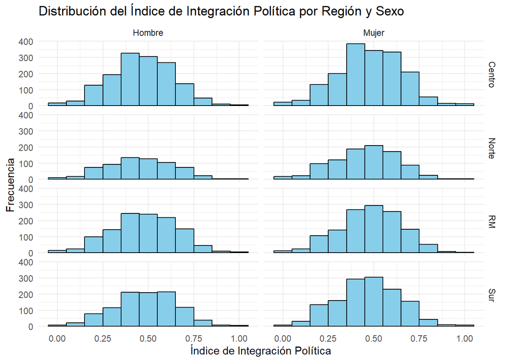

```r
ggplot(datos_finales, aes(x = Indice_Integracion)) +
  geom_histogram(binwidth = 0.1, fill = "skyblue", color = "black") +
  facet_grid(rows = vars(Regiones), cols = vars(Sexo)) +
  labs(title = "Distribución del Índice de Integración Política por Región y Sexo",
       x = "Índice de Integración Política",
       y = "Frecuencia") +
  theme_minimal()
```

### Paso 7.5 - Histograma por Region

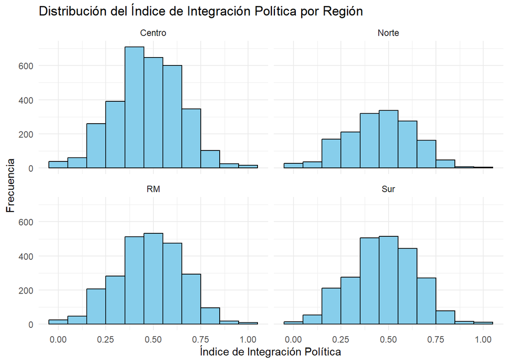

```r
ggplot(datos_finales, aes(x = Indice_Integracion)) +
  geom_histogram(binwidth = 0.1, fill = "skyblue", color = "black") +
  facet_wrap(~ Regiones, ncol = 2) +  # Dividir por región
  labs(title = "Distribución del Índice de Integración Política por Región",
       x = "Índice de Integración Política",
       y = "Frecuencia") +
  theme_minimal()
```